# Questionnaire Report for Arrowtooth Flounder

(MERA version 5.4.3)

Roberto Licandeo (robertolicandeo@gmail.com)

2019-11-26

# About this document

This is a prototype of an automatic report that documents how the user specified the operating model and their various justifications.

# Introduction

1. Describe the history and current status of the fishery, including fleets, sectors, vessel types and practices/gear by vessel type, landing ports, economics/markets, whether targeted/bycatch, other stocks caught in the fishery. Arrowtooth Flounder are an important component of the bottom trawl fishery, although they are also encountered by hook and line fisheries, particularly those targeting Pacifc Halibut (Hippoglossus stenolepis). Information cover management areas 3CD (West Coast Vancouver Island), 5AB (Queen Charlotte Sound), 5CD (Hecate Strait), and 5E (West Coast Haida Gwaii). Prior to the introduction of freezer trawlers in the mid-2000s, most of the historical catch of Arrowtooth Flounder is understood to have been discarded at sea. This was largely due to proteolysis. Catch data prior to the introduction of at-sea observers in 1996 were considered too unreliable for inclusion in the assessment due to unknown quantities of discarding at sea. The assessment fits a female only Bayesian age-structured model to catch,survey and age-composition data from the years 1996-2014.Management advice is provided in the form of decision tables. They are managed as a coastwide stock, with a TAC of 15,000t and catch of 10,679t in 2014. there is a information in the short time series of available data to resolve the population scale/ productivity. The magnitude of catch and discards prior to1996 is a major source of uncertainty.
2. Describe the stock’s ecosystem functions, dependencies, and habitat types. The second largest groundfish TAC in British Columbia after Pacifc Hake(Merluccius productus).
3. Provide all relevant reference materials, such as assessments, research, and other analysis. Grandin, C. and Forrest, R. 2017. Arrowtooth Flounder (Atheresthes stomias) Stock Assessment for the West Coast of British Columbia. DFO Can. Sci. Advis. Sec. Res. Doc. 2017/025. v + 87 p.

# Fishery Characteristics

## Longevity

| Answered |
| --- |
| Very short-lived (5 < maximum age < 7) |
| Short-lived (7 < maximum age < 10) |
| Moderate life span (10 < maximum age < 20) |
| Moderately long-lived (20 < maximum age < 40) |
| Long-lived (40 < maximum age < 80) |
| Very long-lived (80 < maximum age < 160) |

| Justification |
| --- |
| The maximum observed age is 25y for females and 20y for males (p2, Grandin and Forrest 2017). Posterior estimates for M is 0.314, so I included the Moderate life span. |

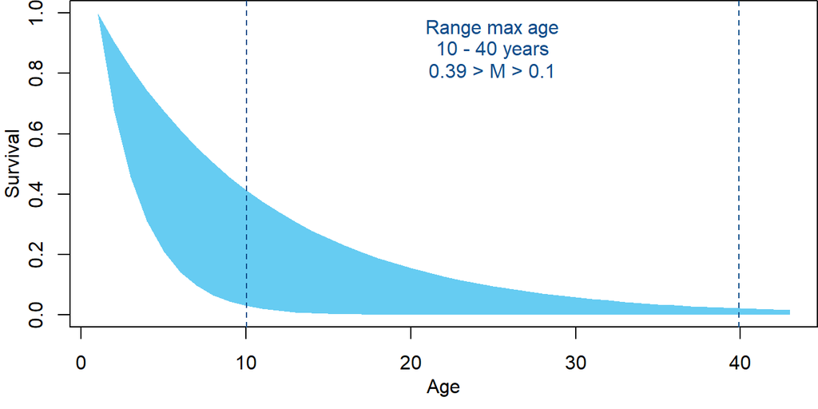

## Stock depletion

| Answered |
| --- |
| Crashed (D < 0.05) |
| Very depleted (0.05 < D < 0.1) |
| Depleted (0.1 < D < 0.15) |
| Moderately depleted (0.15 < D < 0.3) |
| Healthy (0.3 < D < 0.5) |
| Underexploited (0.5 < D) |

[output not shown]

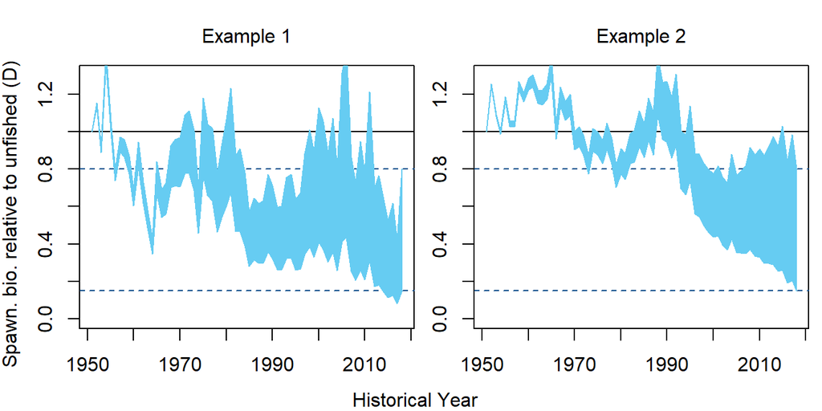

## Resilence

| Answered |
| --- |
| Not resilient (steepness < 0.3) |
| Low resilience (0.3 < steepness < 0.5) |
| Moderate resilence (0.5 < steepness < 0.7) |
| Resilient (0.7 < steepness < 0.9) |
| Very Resilient (0.9 < steepness) |

[output not shown]

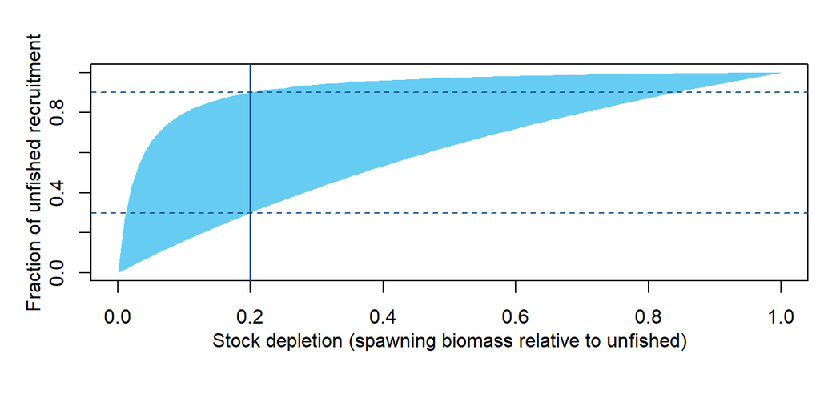

## Historical effort pattern

| Answered |
| --- |
| Stable |
| Two-phase |
| Boom-bust |
| Gradual increases |
| Stable, recent increases |
| Stable, recent declines |

| Justification |
| --- |
| see fig 22. I couldn’t mimic the relative fishing effort |

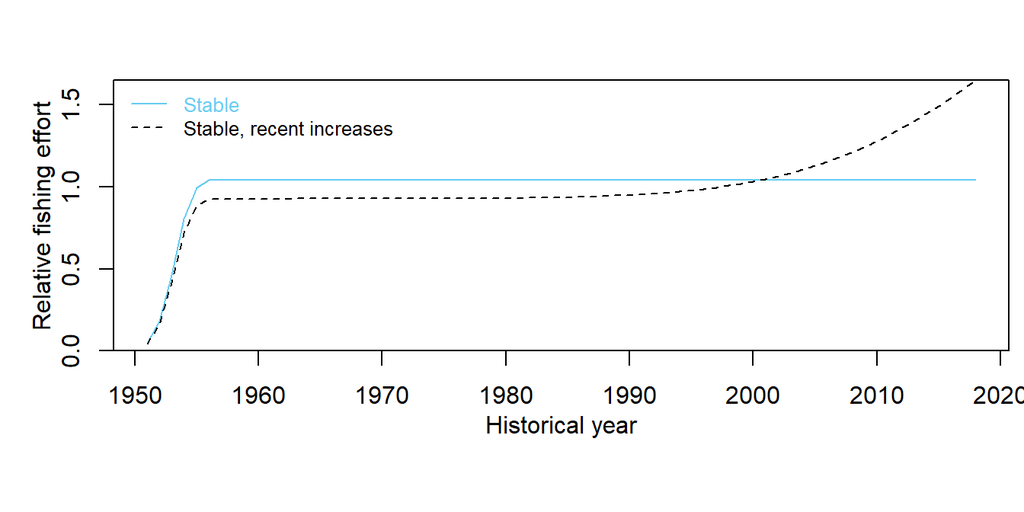

## Inter-annual variability in historical effort

| Answered |
| --- |
| Not variable (less than 20% inter-annual change (IAC)) |
| Variable (maximum IAC between 20% to 50%) |
| Highly variable (maximum IAC between 50% and 100%) |

| Justification |
| --- |
| Model shows low variability in F (see fig. 2). However, authors suggest that the historical catch series need to reconstructed in order to include appropriate uncertainty (p.21). |

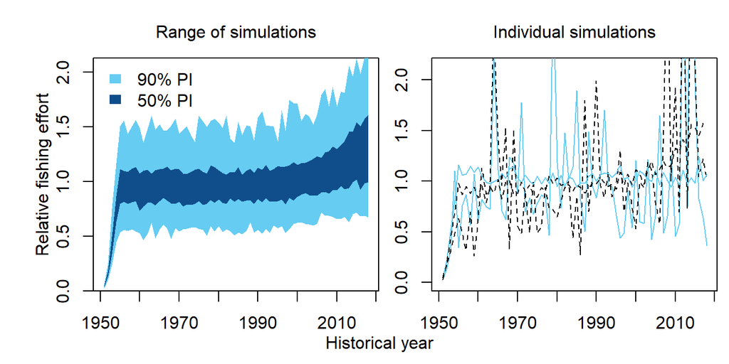

## Historical fishing efficiency changes

| Answered |
| --- |
| Declining by 2-3% pa (halves every 25-35 years) |
| Declining by 1-2% pa (halves every 35-70 years) |
| Stable -1% to 1% pa (may halve/double every 70 years) |
| Increasing by 1-2% pa (doubles every 35-70 years) |
| Increasing by 2-3% pa (doubles every 25-35 years) |

[output not shown]

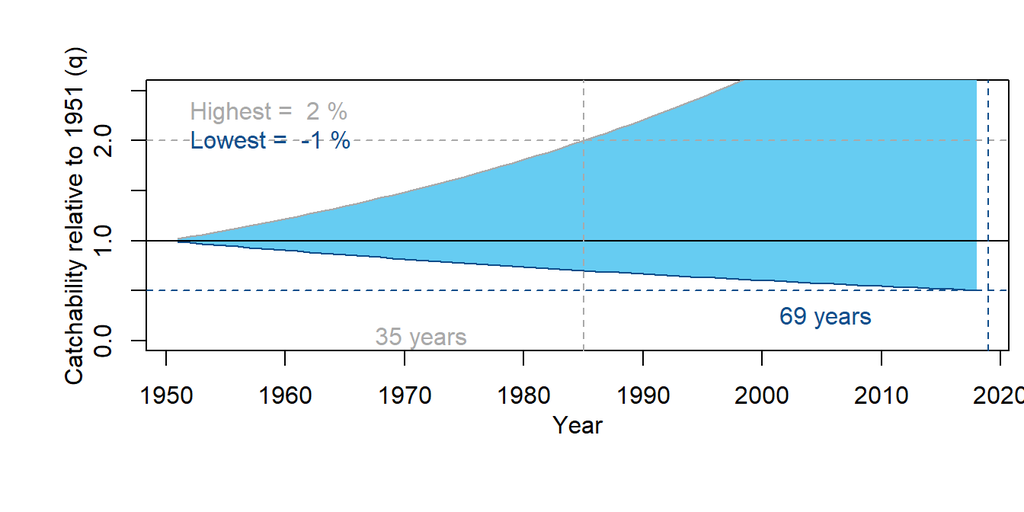

## Future fishing efficiency changes

| Answered |
| --- |
| Declining by 2-3% pa (halves every 25-35 years) |
| Declining by 1-2% pa (halves every 35-70 years) |
| Stable -1% to 1% pa (may halve/double every 70 years) |
| Increasing by 1-2% pa (doubles every 35-70 years) |
| Increasing by 2-3% pa (doubles every 25-35 years) |

[output not shown]

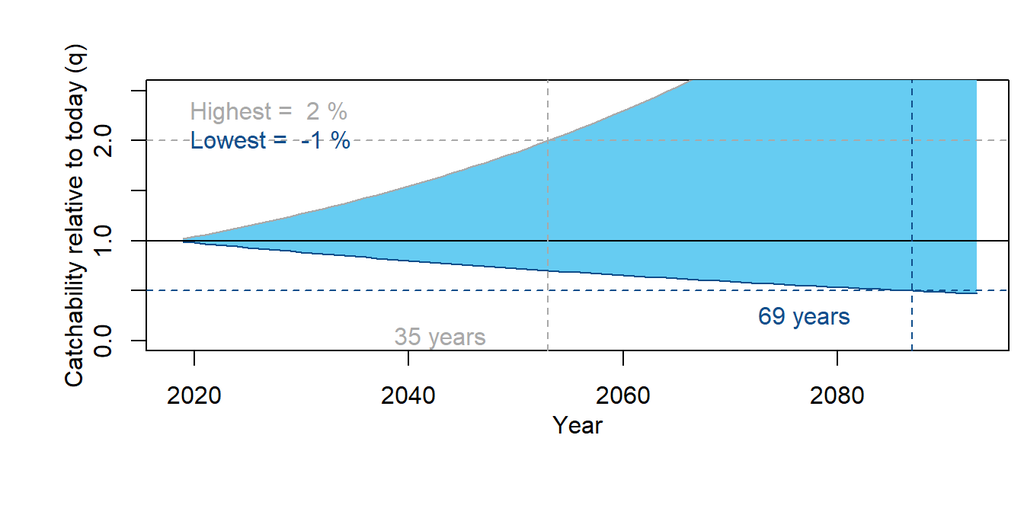

## Length at maturity

| Answered |
| --- |
| Very small (0.4 < LM < 0.5) |
| Small (0.5 < LM < 0.6) |
| Moderate (0.6 < LM < 0.7) |
| Moderate to large (0.7 < LM < 0.8) |
| Large (0.8 < LM < 0.9) |

[output not shown]

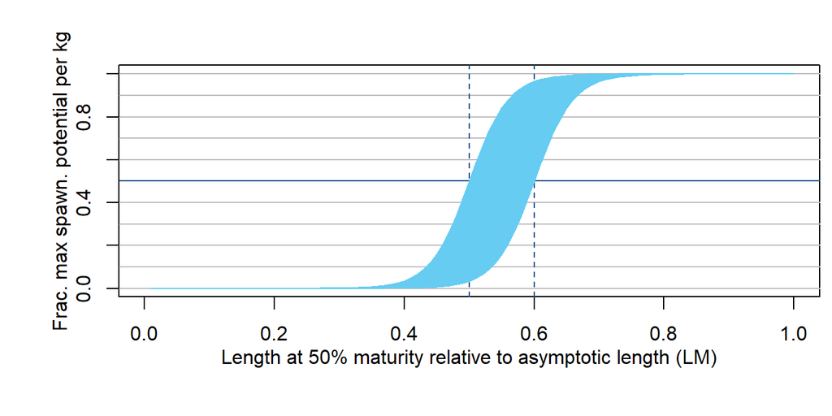

## Selectivity of small fish

| Answered |
| --- |
| Very small (0.1 < S < 0.2) |
| Small (0.2 < S < 0.4) |
| Half asymptotic length (0.4 < S < 0.6) |
| Large (0.6 < S < 0.8) |
| Very large (0.8 < S < 0.9) |

Justification

the estimated age-at-50%-harvest in the trawl fishery (median =9.40y) was consistent with the fishery age composition data (Figure3) but that these data may not be representative of ages in the freezer trawl fleet due to lack of age samples.  
Authors suggest: 1) selectivity ogive = maturity ogive (Scenario 12); 20 age-at-50%-harvest = 6y (Scenario 13) (p18)  
here: 5.6/25 = 0.224 (Age-at-50%-maturity for females /maximum observed age)

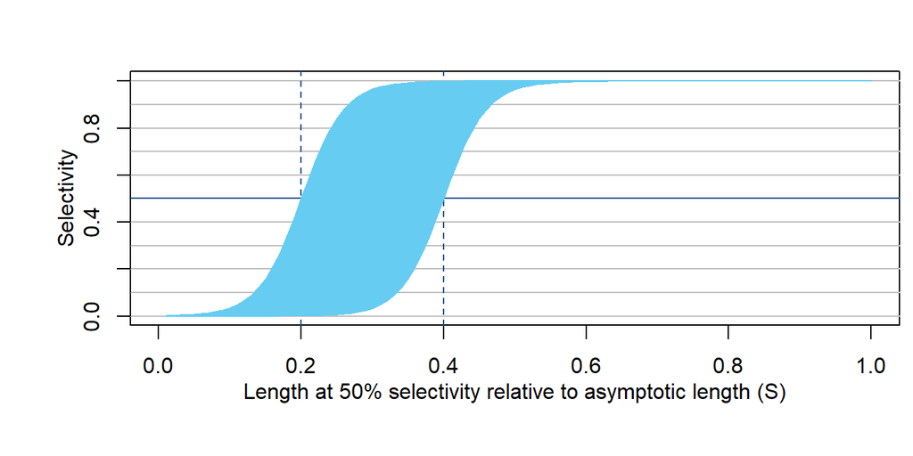

## Selectivity of large fish

| Answered |
| --- |
| Asymptotic selectivity (SL = 1) |
| Declining selectivity with length (0.75 < SL < 1) |
| Dome-shaped selectivity (0.25 < SL < 0.75) |
| Strong dome-shaped selectivity (SL < 0.25) |

| Justification |
| --- |
| all the selectivities were Asymptotic (see fig 17) |

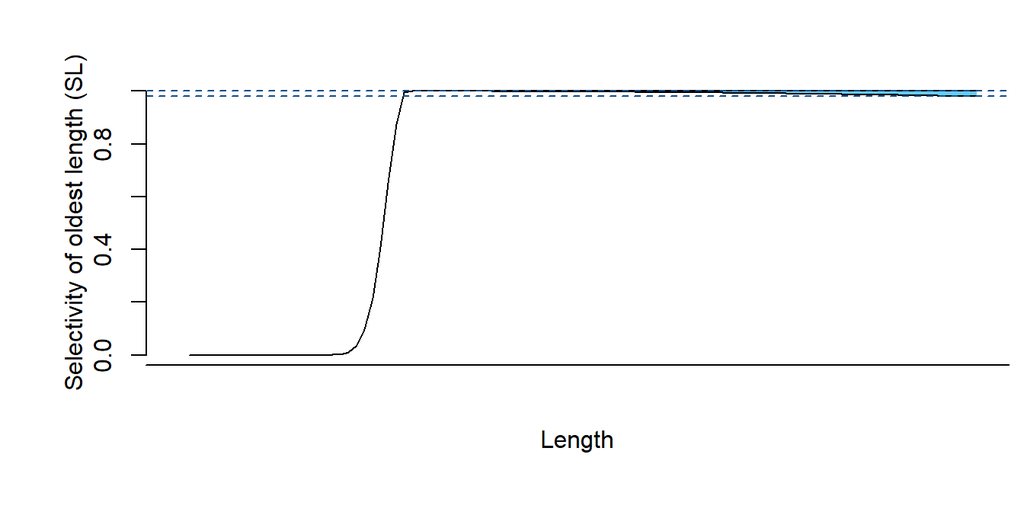

## Discard rate

| Answered |
| --- |
| Low (DR < 1%) |
| Low - moderate (1% < DR < 10%) |
| Moderate (10% < DR < 30%) |
| Moderate - high (30% < DR < 50%) |
| High (50% < DR < 70%) |

Justification

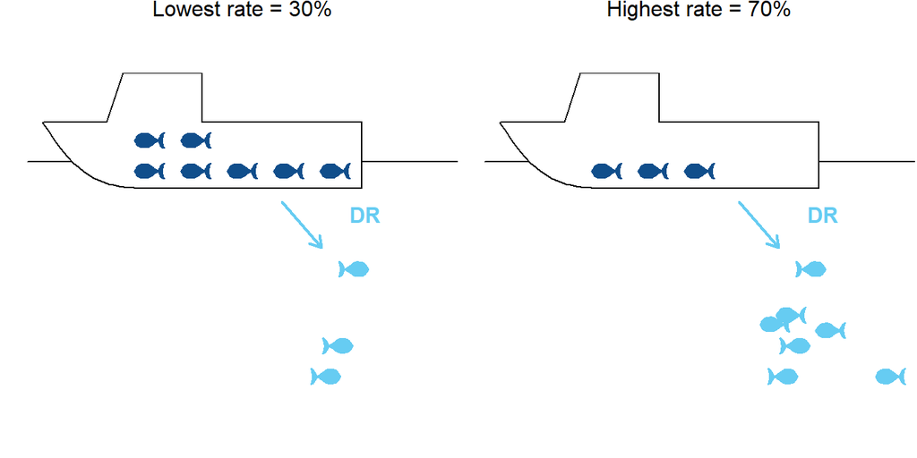

## Post-release mortality rate

| Answered |
| --- |
| Low (PRM < 5%) |
| Low - moderate (5% < PRM < 25%) |
| Moderate (25% < PRM < 50%) |
| Moderate - high (50% < PRM < 75%) |
| High (75% < PRM < 95%) |
| Almost all die (95% < PRM < 100%) |

| Justification |
| --- |
| I need to ask |

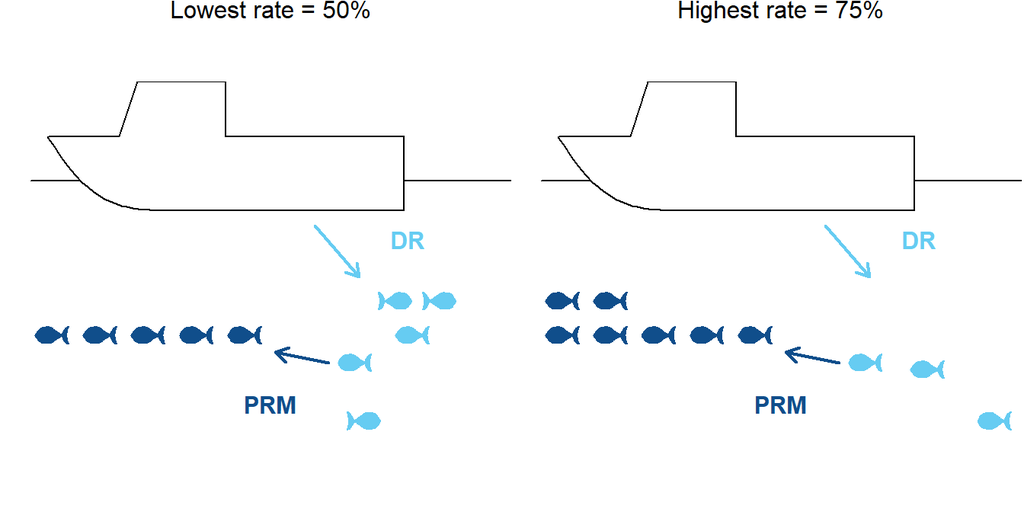

## Recruitment variability

| Answered |
| --- |
| Very low (less than 20% inter-annual changes (IAC)) |
| Low (max IAC of between 20% and 60%) |
| Moderate (max IAC of between 60% and 120%) |
| High (max IAC of between 120% and 180%) |
| Very high (max IAC greater than 180%) |

| Justification |
| --- |
| process error = 0.8 (p15) |

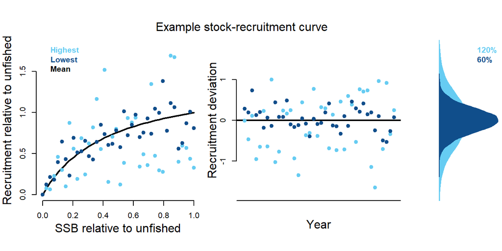

## Size of an existing MPA

| Answered |
| --- |
| None |
| Small (A < 5%) |
| Small-moderate (5% < A < 10%) |
| Moderate (10% < A < 20%) |
| Large (20% < A < 30%) |
| Very large (30% < A < 40%) |
| Huge (40% < A < 50%) |

| Justification |
| --- |
| No justification was provided |

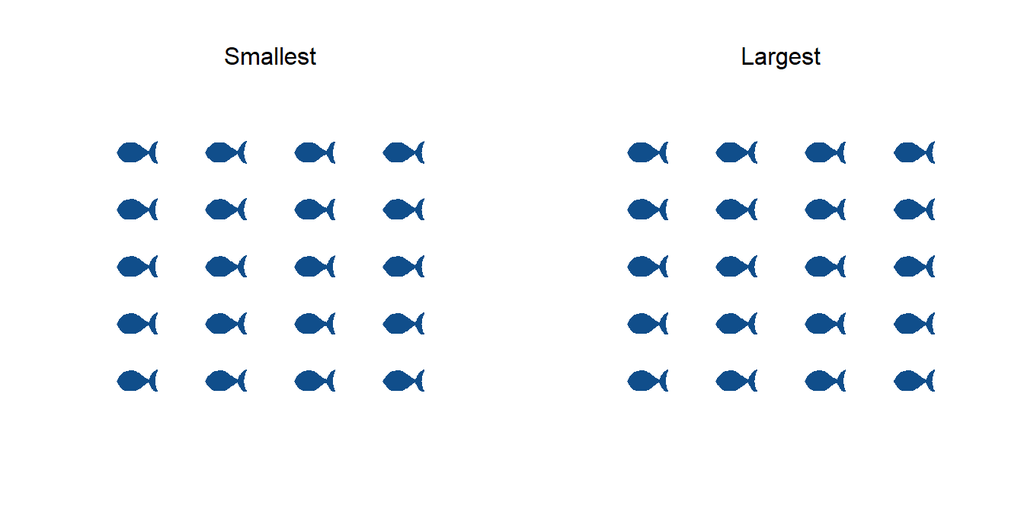

## Spatial mixing (movement) in/out of existing MPA

| Answered |
| --- |
| Very low (P < 1%) |
| Low (1% < P < 5%) |
| Moderate (5% < P < 10%) |
| High (10% < P < 20%) |
| Fully mixed |

| Justification |
| --- |
| No justification was provided |

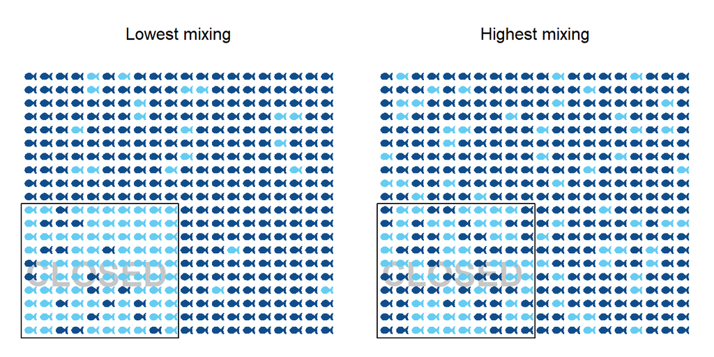

## Size of a future potential MPA

| Answered |
| --- |
| None |
| Small (A < 5%) |
| Small-moderate (5% < A < 10%) |
| Moderate (10% < A < 20%) |
| Large (20% < A < 30%) |
| Very large (30% < A < 40%) |
| Huge (40% < A < 50%) |

| Justification |
| --- |
| No justification was provided |

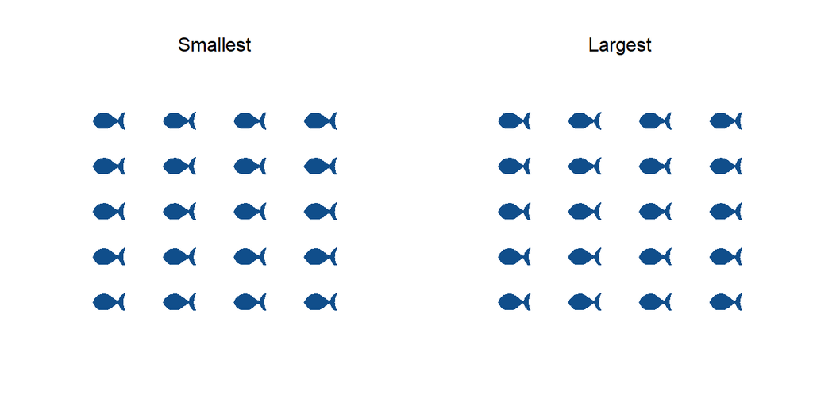

## Spatial mixing (movement) in/out of future potential MPA

| Answered |
| --- |
| Very low (P < 1%) |
| Low (1% < P < 5%) |
| Moderate (5% < P < 10%) |
| High (10% < P < 20%) |
| Fully mixed |

| Justification |
| --- |
| No justification was provided |

[figure not shown]

## Initial stock depletion

| Answered |
| --- |
| Very low (0.1 < D1 < 0.15) |
| Low (0.15 < D1 < 0.3) |
| Moderate (0.3 < D < 0.5) |
| High (0.5 < D1) |
| Asymptotic unfished levels (D1 = 1) |

| Justification |
| --- |
| The magnitude of catch and discards prior to1996 is a major source of uncertainty in this assessment that could provide critical information about the scale and productivity of this stock. |

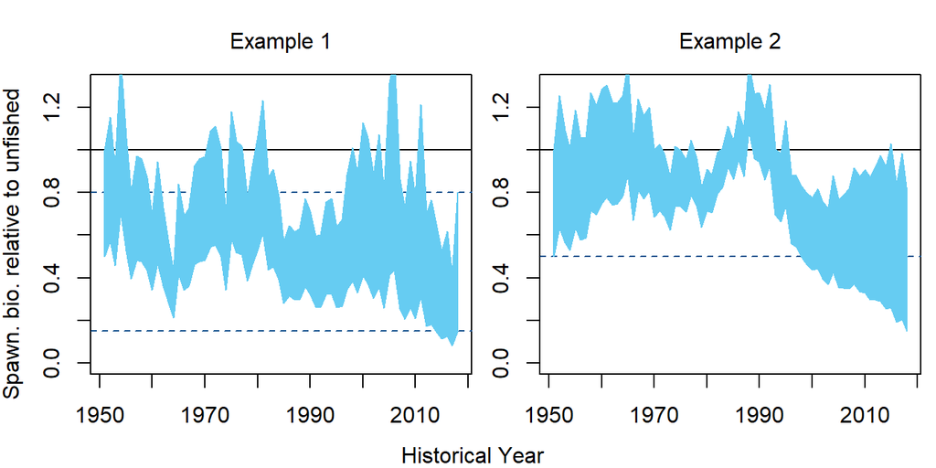

# Management Characteristics

## Types of fishery management that are possible

| Answered |
| --- |
| TAC (Total Allowable Catch): a catch limit |
| TAE (Total Allowable Effort): an effort limit |
| Size limit |
| Time-area closures (a marine reserve) |

Justification

1. Describe what, if any, current management measures are used to constrain catch/effort.  
They are managed as a coastwide stock, with a TAC of 15,000t and catch of 10,679t in 2014  
2. Describe historical management measures, if any.  
Arrowtooth Flounder has been managed on a status-quo basis in recent years, with an annual allocation of 15,000tforthegroundfshtrawl feet since 2006.Before that time, there were no limits on catches or discards of Arrowtooth Flounder.  
3. Describe main strengths and weaknesses of current monitoring and enforcement capacity.  
Prior to the introduction of freezer trawlers, most of the historical catch of Arrowtooth Flounder is understood to have been discarded at sea in large quantities due to proteolysis of the fesh if catches were not landed and frozen quickly after capture. Prior to the introduction of 100% at-sea observer coverage in theBritish Columbia groundfsh feetin1996, reporting of Arrowtooth Flounder discards in fishery logbooks was voluntary. Since Arrowtooth Flounder were not managedwithquotasbefore1996,there was little incentive for skippers to record discards. Therefore the quantity of discards in the pre-1996 period is highly uncertain  
4. Describe and reference any legal/policy requirements for management, monitoring and enforcement.

## TAC offset: consistent overages/underages

| Answered |
| --- |
| Large underages (40% - 70% of recommended) |
| Underages (70% - 90% of recommended) |
| Slight underages (90% - 100% of recommended) |
| Taken exactly (95% - 105% of recommended) |
| Slight overages (100% - 110% of recommended) |
| Overages (110% - 150% of recommended) |
| Large overages (150% - 200% of recommended) |

| Justification |
| --- |
| Since 2006, an annual allocation of 15,000t is given to the groundfish trawl fleet. However, Table 1 and Figure 2 show that the TAC is not taken |

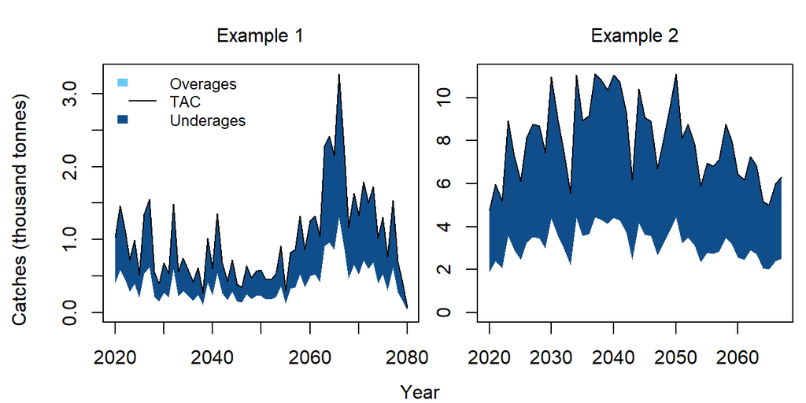

## TAC implementation variability

| Answered |
| --- |
| Constant (V < 1%) |
| Not variable (1% < V < 5%) |
| Low variability (5% < V < 10%) |
| Variable (10% < V < 20%) |
| Highly variable (20% < V < 40%) |

| Justification |
| --- |
| high variability is observed between the TAC and then actual landing (catches + discarding) (see Table 1 and Fig. 2) |

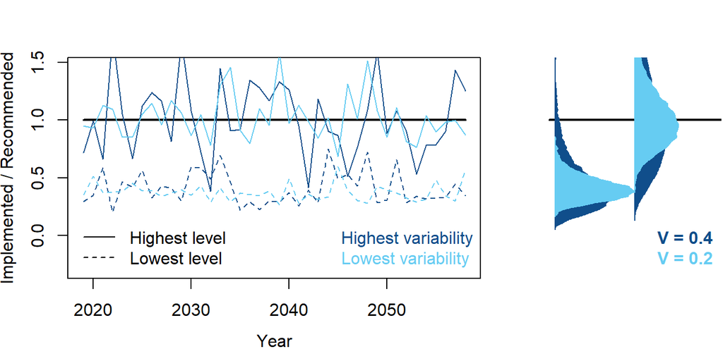

## TAE offset: consistent overages/underages

| Answered |
| --- |
| Large underages (40% - 70% of recommended) |
| Underages (70% - 90% of recommended) |
| Slight underages (90% - 100% of recommended) |
| Taken exactly (95% - 105% of recommended) |
| Slight overages (100% - 110% of recommended) |
| Overages (110% - 150% of recommended) |
| Large overages (150% - 200% of recommended) |

| Justification |
| --- |
| No justification was provided |

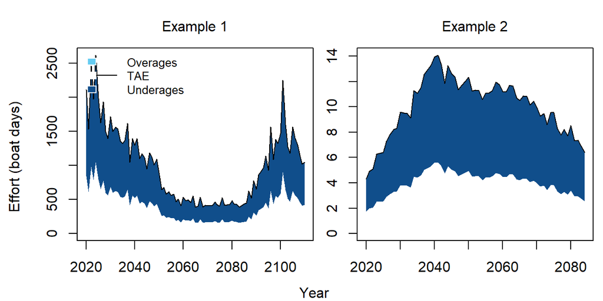

## TAE implementation variability

| Answered |
| --- |
| Constant (V < 1%) |
| Not variable (1% < V < 5%) |
| Low variability (5% < V < 10%) |
| Variable (10% < V < 20%) |
| Highly variable (20% < V < 40%) |

| Justification |
| --- |
| No justification was provided |

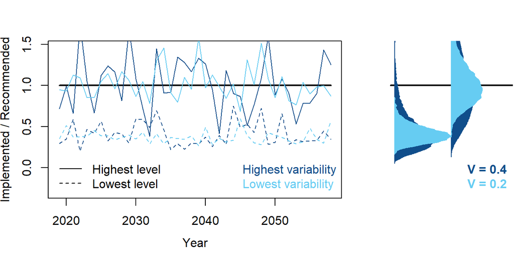

## Size limit offset: consistent overages/underages

| Answered |
| --- |
| Much smaller (40% - 70% of recommended) |
| Smaller (70% - 90% of recommended) |
| Slightly smaller (90% - 100% of recommended) |
| Taken exactly (95% - 105% of recommended) |
| Slightly larger (100% - 110% of recommended) |
| Larger (110% - 150% of recommended) |
| Much larger (150% - 200% of recommended) |

[output not shown]

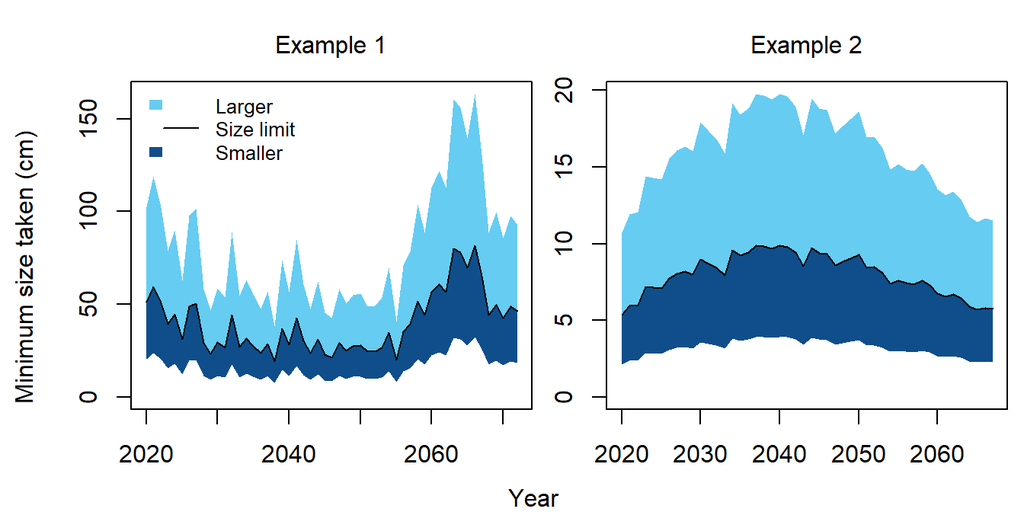

## Size limit implementation variability

| Answered |
| --- |
| Constant (V < 1%) |
| Not variable (1% < V < 5%) |
| Low variability (5% < V < 10%) |
| Variable (10% < V < 20%) |
| Highly variable (20% < V < 40%) |

| Justification |
| --- |
| for the reference model, the maturity at age is lower than the vulnerability at age for the trawl fishery. this consistent with samples taken from freezer trawler and shoreside vessels |

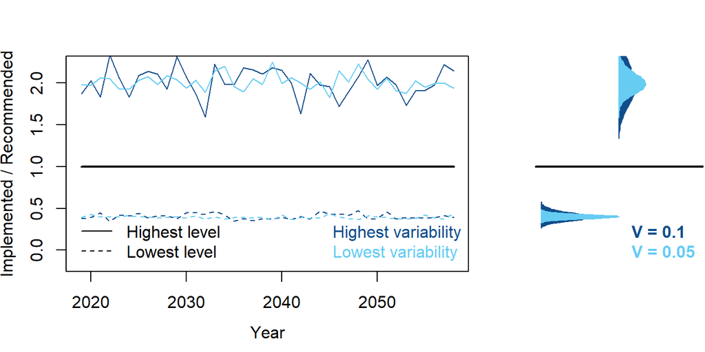

# Data Characteristics

## Available data types

| Answered |
| --- |
| Historical annual catches (from unfished) |
| Recent annual catches (at least 5 recent years) |
| Historical relative abundance index (from unfished) |
| Recent relative abundance index (at least 5 recent years) |
| Fishing effort |
| Size composition (length samples) |
| Age composition (age samples) |
| Growth (growth parameters) |
| Absolute biomass survey |

Justification

1. Provide the time series (specify years, if possible) that exist for catch, effort, and CPUE/abundance indices.  
Commercial fishing data are present for the 1996 to 2014 (see Table 1). See Table 3 for Annual female-only indices of abundance and CVs for the four indices use in the assessment. see Fig. 3 and 4 for the age comps for the fishery and surveys  
2. Describe how these data collected (e.g., log books, dealer reporting, observers).  
fishery independent surveys. details are given in p4-5.  
3. Describe what types of sampling programs and methodologies exist for data collection, including the time-series of available sampling data and quality.  
Details are given in p4-5.  
4. Describe all sources of uncertainty in the status, biology, life history and data sources of the fishery. Include links to documentation, reports.  
Main uncertainties corresponds to historical catches and discarding. short time-series of abundance indices.

## Catch reporting bias

| Answered |
| --- |
| Strong under-reporting (30% - 50%) |
| Under-reporting (10% - 30%) |
| Slight under-reporting (0% - 10%) |
| Reported accurately (+/- 5%) |
| Slight over-reporting (less than 10%) |

[output not shown]

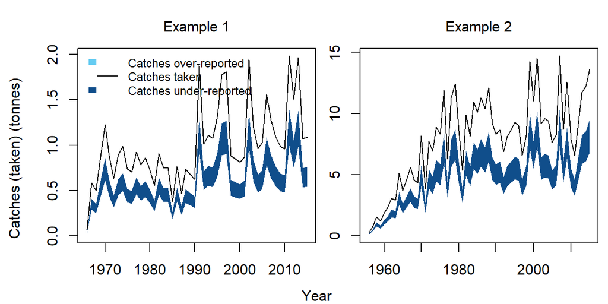

## Hyperstability in indices

| Answered |
| --- |
| Strong hyperdepletion (2 < Beta < 3) |
| Hyperdepletion (1.25 < Beta < 2) |
| Proportional (0.8 < Beta < 1.25) |
| Hyperstability (0.5 < Beta < 0.8) |
| Strong hyperstability (0.33 < Beta < 0.5) |

| Justification |
| --- |
| Survey biomass indices were treated as relative abundance indices that are directly proportional to the survey vulnerable biomass at the beginning of each year (p8) |

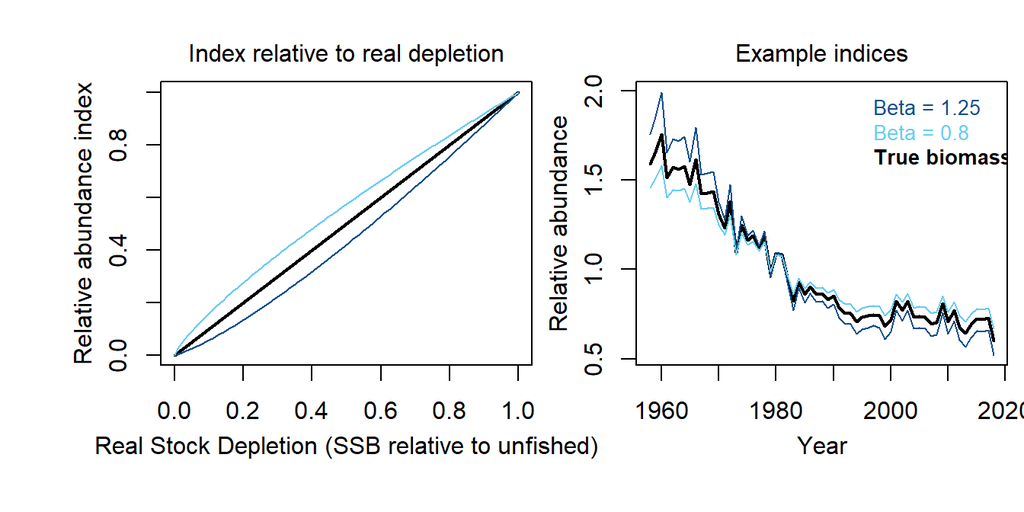

## Available data types

| Answered |
| --- |
| Perfect |
| Good (accurate and precise) |
| Data moderate (some what inaccurate and imprecise) |
| Data poor (inaccurate and imprecise) |

Justification

Surveys CVs are relative low (0.136-0.364) but the time-series are very short. More important, there is not catches/landings (+ discarding) information prior to 1996. In all scenarios, there was strong confounding among parameters representing productivity and scale of the population, indicating that there was limited information in the short time series of available data to resolve the population scale (ABSTRACT)

# Version Notes

The package is subject to ongoing testing. If you find a bug or a problem please send a report to t.carruthers@oceans.ubc.ca so that it can be fixed!

tcar_-2019-11-26-10:25:40

Open Source, GPL-2 2019